# Analysis Of Hockey Plus-Minus Using Linear Regression

Reading the data from several different csv files. Formatting the data into one data set

```r
#load the data and power play data
data <- read.csv("Data/2007-2017.csv")
data_PP <- read.csv("Data/2007-2017_PP.csv")
#create row names
rownames(data) <- (data$Player)
```

```r
#match data by player name between files
playerID = match(row.names(data), data_PP$Player)
##add power play data
data$PP_G = data_PP$G[playerID]
data$PP_A = data_PP$A[playerID]
data$PP_G...=data_PP$G...[playerID]
data$PP_GA=data_PP$GA[playerID]
data$PP_GF=data_PP$GF[playerID]
```

```r
#Adding salary and Position
##import salary data
salary <- read_csv("Data/Names.csv",
    col_names = FALSE)
playerID = match(row.names(data), salary$X1)
data$Salary = salary$X2[playerID]
##make values numbers
data$Salary = as.numeric(data$Salary)
#seperate Defence from Forwards
Defence <- read_csv("Data/Defence.csv")
##create new column that holds D
Defence$Pos = rep('Defence',length(Defence$Player))
playerID = match(row.names(data), Defence$Player)
data$Pos = Defence$Pos[playerID]
#Identify the forwards
data$Pos[is.na(data$Pos)] <- 'Forward'
new = subset(data, !is.na(data$Salary))
```

Figure 1 is a kernel density plot for players accumulated plus-minus separated by position. The data appears to be relatively normally distributed. Forwards are a bit more skewed.

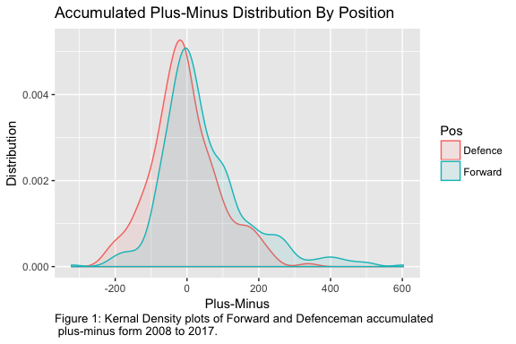

```r
#Density plot for plus-minus by position
caption = "Figure 1: Kernal Density plots of Forward and Defenceman accumulated plus-minus form 2008 to 2017."
ggplot(new,aes(G..., colour = Pos, fill = Pos))+
  geom_density(alpha = 0.1)+
  labs(title = "Accumulated Plus-Minus Distribution By Position", caption = "Figure 1: Kernal Density plots of Forward and Defenceman accumulated\n plus-minus form 2008 to 2017.")+ xlab("Plus-Minus") + ylab("Distribution") + theme(plot.caption = element_text(hjust=0)) #hjust moves caption to left
```

Model 1:
$$Accumulated PlusMinus =\beta_0+\beta_1\times Salary+\beta_2 \times Position + \epsilon$$

```r
##linearmodel with Salary and Position
lm_Pos = lm(G...~ Pos + Salary,data=new)
```

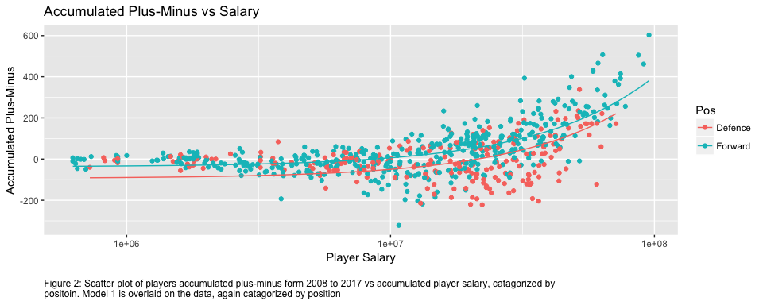

```r
library(stringr)
#Plot accumulated plus-minus agains salary, color by positions and overlay Model 1
#fit the predicted values
pred = data.frame(G... = predict(lm_Pos))
playerID = match(row.names(pred), new$Player)
pred$Salary = new$Salary[playerID]
pred$Pos = new$Pos[playerID]
#plot
caption = "Figure 2: Scatter plot of players accumulated plus-minus form 2008 to 2017 vs accumulated player salary, catagorized by positoin. Model 1 is overlaid on the data, again catagorized by position"
ggplot(data,aes(x=Salary, y=G..., color = Pos))+
  geom_point()+
  ggtitle("Career Plus-Minus vs Salary By Position")+ xlab("Salary") + ylab("PM")+
  scale_x_log10()+
  geom_line(data=pred)+
  ggtitle("Accumulated Plus-Minus vs Salary")+ xlab("Player Salary") + ylab("Accumulated Plus-Minus")+
  labs(caption = str_wrap(caption,120))+theme(plot.caption=element_text(size=9, hjust=0, margin=margin(t=15)))
```

```r
NA
```

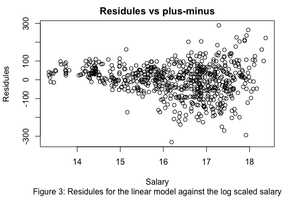

```r
#summary(lm_Pos)
plot(x=log(new$Salary),y=resid(lm_Pos), main="Residules vs plus-minus",sub="Figure 3: Residules for the linear model against the log scaled salary", xlab = "Salary", ylab = "Residules")
```

```r
#plot(density(resid(lm_Pos))) # density distribution, clearly more higher negative residules
#want to look more uniform
#how to deal wwith skew regression coefi
#AIC(lm_Pos) #AIC decreases
```

```r
#summary table model 1
lm_Pos %>% tidy(conf.int = TRUE) %>% knitr::kable(digits = 100, col.names = c("Terms", "Estimates", "Std Error","Wald Statistic","P-Value",".05 Confidence", ".95 Confidence"), caption = "Table 1: Summary statistics for Model 1")
```

| Terms | Estimates | Std Error | Wald Statistic | P-Value | .05 Confidence | .95 Confidence |
| --- | --- | --- | --- | --- | --- | --- |
| (Intercept) | -9.379708e+01 | 6.722286e+00 | -13.953152 | 5.454847e-39 | -1.069966e+02 | -8.059758e+01 |
| PosForward | 5.604918e+01 | 6.838815e+00 | 8.195745 | 1.283956e-15 | 4.262088e+01 | 6.947749e+01 |
| Salary | 4.390840e-06 | 1.910186e-07 | 22.986455 | 1.807552e-86 | 4.015767e-06 | 4.765913e-06 |

Figure 4 is a kernel density plot for players average plus-minus separated by position. The data appears to be relatively normally distributed. Both distributions could be a mixture of two different distributions.

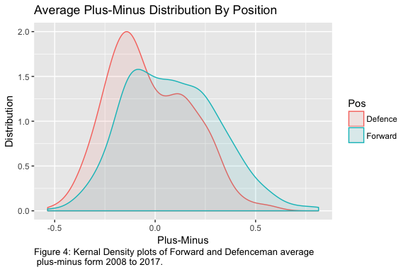

```r
# Average plus-minus per game
#create +/- per game data
data$G...game = data$G.../data$GP
new = subset(data, !is.na(data$Salary))
ggplot(new,aes(G...game, colour = Pos, fill = Pos))+
  geom_density(alpha = 0.1)+
  labs(title = "Average Plus-Minus Distribution By Position", caption = "Figure 4: Kernal Density plots of Forward and Defenceman average\n plus-minus form 2008 to 2017.")+ xlab("Plus-Minus") + ylab("Distribution") + theme(plot.caption = element_text(hjust=0)) #hjust moves caption to left
```

Figure 5 is a scatter plot between plus-minus per game and player salary. Again salary is set to a log scale. There is a slight positive relationship between plus-minus per game and salary. Model 2 is a linear regression model with response variable as players plus-minus and response variables salary and position. Model 2 is overlaid on observed data in Figure 5.